# Análisis del Impacto del Programa Prospera en sus Beneficiarios

Marisol Nava León 125149

Daniela Brito Calderon 198067

Coral Hernández Reyes 191896

Gaspar Samuel Salazar Salgado 191917

28 mayo 2021

# Resumen

La idea central del presente estudio es encontrar el impacto del programa gubernamental PROSPERA mediante la metodología Causal Machine Learning que permite identificar los grupos potencialmente más impactados y las causas de ello. El análisis se hace a partir de la encuesta de gastos e ingresos del inegi 2018 y los principales hallazgos seran presentados a continuación.

# Introducción

El desarrollo social en México ha sido un tema relevante en los últimos años, el cual se ha medido a partir del Índice de Pobreza del Consejo Nacional de Evaluación (CONEVAL) y dados los resultados se ha convertido en prioridad en la agenda pública del gobierno mexicano. Actualmente sufrimos un retraso significativo en cuanto a cubrir las necesidades básicas de una vida digna; tan sólo en el 2018, la población que se encuentra en pobreza en México, fueron 52 millones de personas y 8.6 millones de personas conforman la población vulnerable por ingresos. La importancia de atacar esta problemática social es poder romper el ciclo intergeneracional de la pobreza que continúa generando desigualdad social.

El programa social PROSPERA nace en el año 1997 como el Programa de Educación, Salud y Alimentación (PROGRESA) con una cobertura de 300 mil familias en viviendas rurales, con el objetivo de fomentar el bienestar económico, la inclusión laboral, educación, alimentación y salud. En el 2014 se convierte en PRÓSPERA y actualmente brinda recursos en materia de alimentos, becas educativas y apoyos económicos a casi 7 millones de familias alrededor de todo el país.

El objetivo principal del presente trabajo es analizar el impacto que PROSPERA Programa de Inclusión Social en México ha tenido en la población de manera focalizada. Entre los objetivos específicos se encuentran identificar de qué forma benefició a los participantes del programa, hallar las principales características de los hogares que tuvieron un impacto más alto así como las causas de ello. Cabe destacar que la medición del impacto del presente análisis está enfocado en la alimentación, el empleo y la educación del individuo.

Para lograr esto se desarrolla un modelo de Causal Machine Learning el cual permite ser aplicado en predicción e inferir impactos causales; utilizando como base de datos la Encuesta Nacional de Ingresos y Gastos de los Hogares (ENIGH) 2018, del Instituto Nacional de Estadistica, Geografia e Información (INEGI), el cual se presenta en este documento. Posterior a ello se procederá a presentar los resultados de las estimaciones correspondientes, las conclusiones y recomendaciones de la evaluación de impacto.

# Identificación del problema

El programa tiene identificado el problema que busca resolver el cual es: hogares que viven con limitaciones en el ámbito de salud, alimentación y educación debido a recibir un ingreso por debajo de la Línea de Bienestar Mínimo (LBM). La población son todos los hogares que cuenten con integrantes que presenten carencia en algún rubro mencionado anteriormente. La hipótesis de cuál puede ser la parte de esa problemática inicialmente nos basamos en la alimentación, es decir, que una carencia en este ámbito repercute en el estado de la salud y desempeño educativo lo que puede llevar a una mayor probabilidad de 1) tener un empleo informal y 2) no terminar la secundaria. Aunado a esto, en el diagnóstico realizado para la implementación del programa, se encontró que las transferencias monetarias contribuyen a aumentar el consumo de alimentos, las inscripciones escolares y el acceso a instituciones de salud. El programa se encuentra vinculado a los Objetivos de Desarrollo Sostenible de la ONU, lo cual implica que su objetivo es atender la población en pobreza extrema, poner en práctica acciones de protección social, ampliar el acceso a una alimentación sana y nutritiva, procurar que todos los niños y niñas alcancen la educación básica y promover la inclusión social.

# Marco conceptual

Como se mencionó anteriormente, los beneficios del programa son asignados a personas que se encuentran en la pobreza, la cual de acuerdo al CONEVAL se define como persona que tiene al menos una carencia en alguno de los seis indicadores: rezago educativo, accesos a servicios de salud, seguridad social, calidad y espacios de la vivienda, servicios básicos de la vivienda y acceso a la alimentación. El índice de pobreza es calculado a partir de la base de datos proporcionada por el INEGI, razón por la cual utilizaremos dicha información. El Programa PROSPERA a su vez cuenta con información que permite conocer quiénes reciben los apoyos y las características de los beneficiarios establecidas dependiendo si se trata de cada integrante o de las familias.

Adicionalmente, el presente trabajo busca contribuir en las discusiones entre el empleo formal e informal, y si este último es una de las causas de la pobreza. Ciertamente, las actividades informales representan una importante parte del sector laboral y de la población económicamente activa, precisamente en México, en el 2020 este sector llegó a representar 57% del mercado laboral, por lo que la inclusión de la informalidad laboral en el estudio será de gran contribución para este trabajo. Para ello es de suma importancia destacar que la definición de informalidad laboral que el presente estudio tomará como base es la que propone el INEGI, el cual dice que si el trabajador recibe remuneraciones pero no recibe prestaciones de seguridad social, el trabajo se considera informal.

# Datos

La base de datos fue construida a partir del ENIGH 2018, conformado por las tablas: viviendas, población, ingresos, hogares y trabajos. Se tomó en cuenta los folios identificadores como folioviv, foliohog y numren, con la finalidad de concatenar las tablas de manera adecuada.

## Alimentación

Las variables que conforman este rubro se detallan en la encuesta como: 1. Preocupación por que la comida se acabe, 2. Sin comida, 3. Poca variedad de alimentos, 4. Comió menos, 5. Sintió hambre y no comió.

## Educación

Se construyó una variable que indica si el individuo terminó la secundaria o no, esto fue a partir de la variable “nivelaprob” la cual era categórica e indicaba el nivel escolar (primaria,secundaria, preparatoria, etc.) en conjunto con “gradoaprob” la cual era complemento de “nivelaprob” e informava el último año aprobado, con base a estas variables se creó una tercera llamada “secundaria” la cual toma un valor de 1 si como mínimo concluyó el tercer año de secundaria, y toma el valor de 0 cuando máximo conlcuyo hasta segundo año de secundaria.

## Empleo informal

De acuerdo a la definición de inegi presentada anteriormente, tomamos como variable de empleo formal si el individuo cuenta con atención médica (sea Seguro Popular, ISSSTE, IMSS u otro), si el individuo no contó con ningun tipo de seguridad social se le categorizó como empleado informal.

# Características de la base de datos

A continuación se presenta Tabla 1 donde se puede observar las principales características de la definición de pobreza y el comparativo entre el grupo que recibió tratamiento y el que no. Podemos ver que las que toman más peso son si tiene acceso a seguro médico, si tiene o no concluida la secundaria y si cuenta con un trabajo informal.

**Tabla 1. Estadística Descriptivas**

```
## Descriptive Statistics
## Var_sociodem
## Group: prospera = 0
## N: 225944
##
##                                Mean   Std.Dev    Min   Median      Max     N.Valid   Pct.Valid
## --------------------------- ------- --------- ------ -------- -------- ----------- -----------
##       Acceso a alimentacion    0.43      0.49   0.00     0.00     1.00   225944.00      100.00
##                 Alfabetismo    1.00      0.00   1.00     1.00     1.00   200551.00       88.76
##             Atencion medica    1.00      0.00   1.00     1.00     1.00   106720.00       47.23
##                Dispone agua    0.81      0.40   0.00     1.00     1.00   209903.00       92.90
##                        edad   33.59     20.85   3.00    30.00   110.00   225944.00      100.00
##       Habla lengua indigena    1.00      0.00   1.00     1.00     1.00    11523.00        5.10
##                    prospera    0.00      0.00   0.00     0.00     0.00   225944.00      100.00
##                        sexo    1.00      0.00   1.00     1.00     1.00   116675.00       51.64
##          Termino secundaria    0.53      0.50   0.00     1.00     1.00   225944.00      100.00
##        Tiene seguro popular    1.00      0.00   1.00     1.00     1.00    91294.00       40.41
##            Trabajo informal    0.21      0.41   0.00     0.00     1.00   225944.00      100.00
##
## Group: prospera = 1
## N: 29336
##
##                                Mean   Std.Dev    Min   Median      Max    N.Valid   Pct.Valid
## --------------------------- ------- --------- ------ -------- -------- ---------- -----------
##       Acceso a alimentacion    0.59      0.49   0.00     1.00     1.00   29336.00      100.00
##                 Alfabetismo    1.00      0.00   1.00     1.00     1.00   25818.00       88.01
##             Atencion medica    1.00      0.00   1.00     1.00     1.00    5580.00       19.02
##                Dispone agua    0.51      0.50   0.00     1.00     1.00   24902.00       84.89
##                        edad   28.44     19.73   3.00    18.00   107.00   29336.00      100.00
##       Habla lengua indigena    1.00      0.00   1.00     1.00     1.00    4990.00       17.01
##                    prospera    1.00      0.00   1.00     1.00     1.00   29336.00      100.00
##                        sexo    1.00      0.00   1.00     1.00     1.00    7937.00       27.06
##          Termino secundaria    0.34      0.47   0.00     0.00     1.00   29336.00      100.00
##        Tiene seguro popular    1.00      0.00   1.00     1.00     1.00   25730.00       87.71
##            Trabajo informal    0.13      0.34   0.00     0.00     1.00   29336.00      100.00
```

Grafica 1. Necesidades básicas

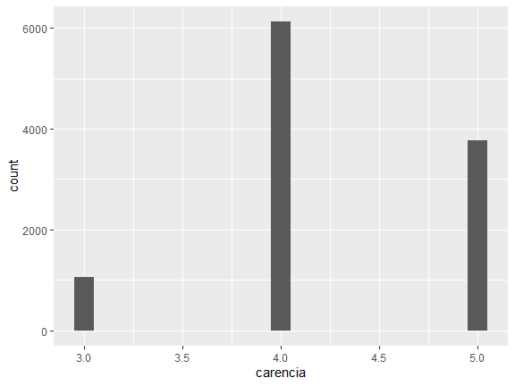

# Correlación

Nuestro siguiente paso fue calcular las correlaciones existentes entre las variables de la base datos, con la finalidad poder eliminar aquellas que identificamos que presentaron mas del 95% de correlación entre ellas, en la Tabla 2.se presentan las susodichas variables.

Tabla 2. Variables con correlación mayor a 95%

**Pares con correlación>95%**

|  | Var1 | Var2 | corr |
| --- | --- | --- | --- |
| 15108 | est_dis | ubica_geo | 0.9985169 |
| 15109 | upm | ubica_geo | 0.9979534 |
| 15486 | ubica_geo | est_dis | 0.9985169 |
| 15490 | upm | est_dis | 0.9972010 |
| 15613 | ubica_geo | upm | 0.9979534 |
| 15616 | est_dis | upm | 0.9972010 |

# Cuantificacion del impacto del programa

Para poder medir el impacto que ha tenido el programa de Prospera seguimos las técnicas de cross-validation, con la finalidad de calcular los efectos promedios del tratamiento tanto en la preocupación de los hogares por la escasez de alimentos, la probabilidad de haber terminado la secundaria y la probabilidad de tener un trabajo informal.

**Tabla 3. Efecto promedio del tratamiento**

```
##
## ==============================================================================
##                                               Dependent variable:
##                                   --------------------------------------------
##                                   acceso_resid secundaria_resid informal_resid
##                                       (1)            (2)             (3)
## ------------------------------------------------------------------------------
## treat_resid                         0.025***      -0.036***       -0.026***
##                                     (0.004)        (0.003)         (0.003)
##
## Constant                            -0.00001       -0.0001          0.001
##                                     (0.001)        (0.001)         (0.001)
##
## ------------------------------------------------------------------------------
## Observations                        178,549        178,549         178,549
## R2                                   0.0002         0.001           0.0004
## Adjusted R2                          0.0002         0.001           0.0004
## Residual Std. Error (df = 178547)    0.462          0.388           0.351
## F Statistic (df = 1; 178547)       38.807***      115.110***      73.694***
## ==============================================================================
## Note:                                              *p<0.1; **p<0.05; ***p<0.01
```

Como complemento calculamos un modelo LASSO que nos pirmitio ver el impacto por individuo el cual se muestra a continuacion.

**Tabla 4. Modelo LASSO**

```
## [1] 178549    280
```

**Variables significativas**

| variable | coeficiente |
| --- | --- |
| intercept | 0.0184604 |
| telefono | -0.0030782 |
| num_van | -0.0001380 |
| num_bici | 0.0017099 |
| num_trici | 0.0102714 |
| num_canoa | 0.0093816 |
| num_otro | 0.0089328 |
| num_ester | -0.0033809 |
| num_radio | -0.0023885 |
| num_licua | -0.0004415 |
| num_micro | -0.0016327 |
| num_estuf | 0.0035936 |
| num_lavad | -0.0022980 |
| num_planc | -0.0033179 |
| num_maqui | 0.0062547 |
| parentesco | 0.0000062 |
| sexo | 0.0026523 |
| edad | -0.0000685 |
| hablaind | 0.0080496 |
| hor_2 | 0.0002360 |
| hor_4 | 0.0001555 |
| hor_6 | 0.0000391 |
| hor_8 | -0.0000080 |
| atemed | -0.0005283 |
| servmed_2 | 0.0056111 |
| servmed_3 | 0.0002855 |
| servmed_6 | -0.0009010 |
| servmed_10 | 0.0010387 |
| servmed_11 | 0.0008805 |
| pagoaten_2 | 0.0003061 |

[output cut: 79 more lines]

**Variables significativas**

| variable | coeficiente |
| --- | --- |
| intercept | -0.0208460 |
| telefono | 0.0039591 |
| celular | -0.0004239 |
| tv_paga | 0.0023181 |
| conex_inte | -0.0007833 |
| num_auto | 0.0009132 |
| num_van | -0.0072686 |
| num_pickup | -0.0065112 |
| num_moto | 0.0001283 |
| num_bici | -0.0003345 |
| num_trici | 0.0067208 |
| num_carret | -0.0095691 |
| num_canoa | 0.0008240 |
| num_otro | 0.0157167 |
| num_ester | -0.0007163 |
| num_grab | -0.0037879 |
| num_tva | -0.0023712 |
| num_tvd | 0.0007047 |
| num_dvd | 0.0024966 |
| num_tosta | -0.0009007 |
| num_micro | 0.0014926 |
| num_refri | 0.0034220 |
| num_estuf | -0.0006726 |
| num_lavad | -0.0046760 |
| num_planc | 0.0051172 |
| num_maqui | 0.0019096 |
| num_venti | 0.0011300 |
| num_aspir | 0.0018411 |
| num_compu | 0.0021990 |
| num_impre | 0.0049602 |

[output cut: 160 more lines]

**Variables significativas**

| variable | coeficiente |
| --- | --- |
| intercept | -0.0388396 |
| celular | 0.0057603 |
| tv_paga | 0.0010306 |
| num_auto | -0.0005637 |
| num_van | -0.0014328 |
| num_pickup | -0.0013121 |
| num_moto | 0.0029350 |
| num_bici | 0.0026479 |
| num_carret | -0.0211108 |
| num_canoa | -0.0244517 |
| num_otro | 0.0034044 |
| num_ester | 0.0009036 |
| num_radio | 0.0016021 |
| num_tva | 0.0007919 |
| num_licua | 0.0003845 |
| num_tosta | 0.0018509 |
| num_micro | -0.0040296 |
| num_refri | -0.0053010 |
| num_estuf | 0.0014895 |
| num_maqui | 0.0029938 |
| num_venti | 0.0003095 |
| num_aspir | 0.0008016 |
| num_compu | -0.0009578 |
| num_impre | -0.0069791 |
| parentesco | -0.0000006 |
| edad | -0.0003627 |
| padre_hog | -0.0038369 |
| hablaind | -0.0138386 |
| alfabetism | 0.0120315 |
| hor_1 | -0.0000279 |

[output cut: 145 more lines]

# Focalización

```
##
##      0      1
## 157757  20792
```

**Tabla 5. Focalización**

```
##
##      0      1
## 170964   7585
```